# The Modifiable Areal Unit Problem: Fulton County, 2020

One county’s census blocks, and what moving the boxes does to the share

Democracy’s Data

Last updated September 13, 2026 at 10:53a EDT

Here is a claim you have met in map form. One map of a city shades each neighborhood by its Black share and shows a place sharply divided. Another shades the same city as a single unit and shows one even tone. Both can be drawn from the same census, taken on the same day, with no error in either. Two honest maps of the same people can tell opposite stories. How?

The how has a name worth learning: the **modifiable areal unit problem**, named by the geographer Stan Openshaw in 1984.[^1] It is the fact that a statistic computed over areas depends on the boxes the people were sorted into, and not only on the people. This brief asks it in its sharpest form. Fulton County, Georgia is 44.78% Black; cut the county into six districts of equal population, and how many are majority-Black? That sounds like a question about Fulton’s people. Whether it is one is the test.

## The test

The test holds the people still and moves only the boxes. The data is the count the Census Bureau took in 2020, in the form it publishes for redistricting: the [2020 Census Redistricting Data (P.L. 94-171) Summary File](https://www2.census.gov/programs-surveys/decennial/2020/data/01-Redistricting_File--PL_94-171/Georgia/ga2020.pl.zip) for Georgia, downloadable from the Bureau’s server at that address, with block boundaries from the Bureau’s TIGER/Line 2020 release, its digital outlines of every census unit. [A 1975 statute](https://www.law.cornell.edu/uscode/text/13/141) obliges the Bureau to deliver this file to every state legislature so the legislature can draw districts. So these pages use the redistricting numbers themselves, in the form Georgia’s map-drawers received them.

Three properties make this file, of all files, the right instrument. It is a complete count rather than a sample, so there are no margins of error below, no allowance for how far off an estimate could be, because nothing is estimated. Its atom, the census block, is the smallest unit the Bureau publishes, so everything larger can be built out of it. And census units nest exactly. A block’s identifier contains the identifiers of its block group (a cluster of neighboring blocks), its tract (a group of block groups, the Bureau’s stand-in for a neighborhood), its county and its state, so climbing that ladder is arithmetic on a string, with no map operation to introduce error. How that machinery works, and where it stops, is the subject of the census geography chapter.

Two experiments follow. The first climbs the ladder: the same blocks, added into block groups, then tracts, then the county, watching what each rung does to the spread of the Black share. That is the **scale effect**, what happens to a statistic as the units it is computed over grow. The second holds the number and size of units fixed and changes only their shapes. That is the **zoning effect**, and it is the one that decides elections, because redrawing shapes while holding population constant is the literal definition of redistricting.

## The data

Everything below rests on one table built here from the Bureau’s raw files: `ga_block_race.csv`, one row per Georgia census block. Its columns, by name: `GEOID20`, the block’s fifteen-character identifier; `pop`, everyone counted there in 2020; `black_alone`; `black_any`; `vap`, the voting-age population; and `black_any_vap`, the voting-age count of any part Black.

One detail of how the table was made changes what you can trust. Every identifier is held as text, because a fifteen-digit identifier read as a number collapses into scientific notation, and a tract identifier silently drops its leading zero.

The Bureau’s file stacks every level of geography in one table, from the state down, with a code on each row saying which level it belongs to. Keeping only the rows coded as blocks leaves 232,717 of them. Nothing was imputed, meaning no value nobody recorded was filled in by guessing. No row was dropped for being empty either: blocks with nobody living on them stay in, all 3,074 of Fulton’s, because how many there are is part of the record.

Two decisions in the table are choices, and they are named. `black_any` counts a person as Black if their answer is any of the 32 of the census’s 63 race combinations that include Black. Counting `black_alone` instead gives Georgia 31.0% rather than 33.03%; voting-rights litigation generally uses any-part, so this brief does too.[^2] And every statistic below is population-weighted: a unit counts as many times as it holds people, so a block of three cannot pull as hard as a tract of six thousand. What the file holds, at the two scales this brief uses:

| Quantity | Value |
| --- | --- |
| Census blocks in Georgia | 232,717 |
| People in Georgia | 10,711,908 |
| Georgians of any part Black | 3,538,146 |
| Census blocks in Fulton County | 11,748 |
| Fulton blocks with anyone living on them | 8,674 |
| People in Fulton County | 1,066,710 |
| Fulton residents of any part Black | 477,624 |
| Fulton share, any part Black (%) | 44.78 |
| Fulton share of voting-age population (%) | 43.51 |

The rest of the folder was made here rather than downloaded, and made data can answer only the question its maker thought to ask. The ladder tables, `ladder_fulton.csv` and `ladder_state.csv`, add the same blocks up four ways, from block to county. The sweep, `zoning_summary.csv`, divides Fulton’s 11,748 blocks into 6 units of 177,785 people each, one sixth of the county apiece, 360 different ways. The ways come from two rules, each rotated through 180 one-degree steps:

| Rule | How | Plans it makes |
| --- | --- | --- |
| Strip | 6 parallel slabs perpendicular to a chosen direction, cut so each slab holds a sixth of the county | 180 rotations |
| Split | Recursive bisection: halve the county, halve each half, halve again, turning 90 degrees each time | 180 rotations |

Neither rule looks at race, or at anything except where people live and which way the ruler points. Every unit of every plan holds a sixth of Fulton to within 0.71% of the quota, the one-sixth target, well inside the tolerance courts allow state legislative and local plans, whose largest and smallest districts may differ by up to about a tenth of a district’s population.[^3]

> **Before you read on, commit to a number.** The same 11,748 blocks, the same 1,066,710 people, 6 units of equal population, and two rules neither of which reads race. **How many of the 6 units will be majority-Black?** Write your number down before you look at the first figure.

## What it says about democracy

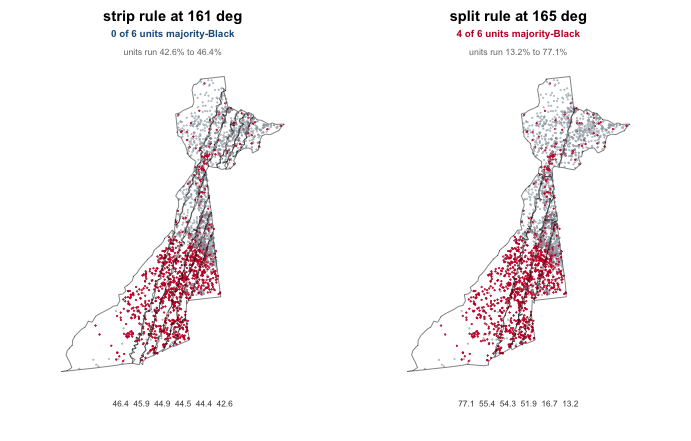

**Figure 1. The same dots, twice, with different lines drawn over them.** Each dot is 400 people; red dots are residents recorded as any part Black. A paired map fits the question because the dots are identical in both panels, the same census, and only the boundaries differ. On the left, the strip rule at 161 degrees gives 6 units running 42.6% to 46.4% Black, and 0 majority-Black. On the right, the split rule at 165 degrees gives units running 13.2% to 77.1%, and 4 of 6 majority-Black.

Most readers commit to two or three, because the county is 44.78% Black and a sixth of it ought to look like the whole. **Across the 360 plans, the answer runs from 0 to 4.**

The left panel is what political scientists call **cracking**, spreading a group across many districts so that it is a majority in none, arrived at here with no intent. The slabs run across the county’s grain, so each one picks up part of the Black south and west and part of the white north. Every unit lands near the county figure and not one is a majority. The right panel cuts with the grain instead. A ruler and a protractor did this; no demographic fact entered either rule.

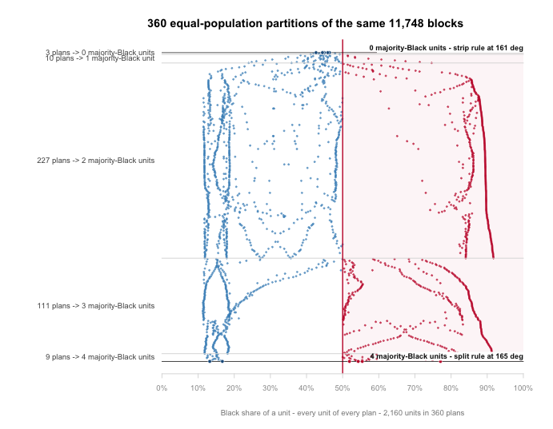

**Figure 2. Every plan in the sweep, sorted by how many of its units are majority-Black.** Each row is one plan and each dot one of its 6 units, placed by the unit’s Black share; dots right of the red 50% line are majority-Black units. The two heavily marked rows are the extremes drawn in Figure 1.

3 of the 360 plans produce no majority-Black unit at all; 9 produce 4; 227 produce exactly two. Same census, same day, same county, same 6 equal populations. The mistake worth naming is not any particular guess. It is assuming the question has *an* answer.

The honest objection is that these are not districts, so test it. Counted strictly, 0 of the 360 plans have all 6 units in one connected piece. That is Georgia’s block layer at work: the riverbed, the interstate and the airport apron get blocks of their own, so any cut anywhere strands a few near-empty blocks.

The criterion that means something is whether a unit’s people form one connected mass. Call a plan effectively contiguous when every unit has at least 99% of its population in one piece: 172 plans pass, and among them the answer still runs from 2 to 3 majority-Black units. The zero-majority plans do not survive the test; the ambiguity does. What is left is a one-seat swing decided by which of two respectable rules you happened to use, and on a 6-seat county commission that is a sixth of the government.

The zoning effect is half of the problem. The other half appears when the same blocks are simply added up the census ladder, with no redrawing at all.

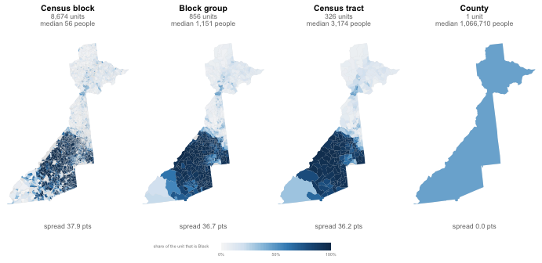

**Figure 3. The same county, the same census, four ideas of what counts as a place.** Fulton County, 2020, shaded by the share of each unit that is any part Black, on one color ramp across all four panels; the four-panel form fits because only the unit changes between them. The left panel is 8,674 inhabited shapes and the right is one shape, holding exactly the same 1,066,710 people. “Spread” beneath each panel is the standard deviation of the units’ Black shares, a measure of how far units sit from the average, weighted by population; it falls from 37.9 points to 0.0.

The population-weighted mean is the control in this experiment: 44.78% at every rung, because the same people are being averaged, only bundled differently. Everything else moves. The spread falls from 37.9 points across blocks to 36.2 across tracts and to 0.0 across the county, where one unit has nothing left to vary. Statewide, the same climb does more than shrink variation:

| Level | Units | Median people | Weighted SD (points) | Most Black unit (%) | Corr with under-18 share |
| --- | --- | --- | --- | --- | --- |
| Census block | 165,333 | 26 | 31.8 | 100.0 | 0.088 |
| Block group | 7,433 | 1,343 | 28.4 | 99.6 | 0.097 |
| Census tract | 2,784 | 3,718 | 27.1 | 98.7 | 0.080 |
| County | 159 | 22,842 | 17.7 | 72.7 | -0.147 |

Two columns of that table are worth more than they look. The most Black unit in Georgia falls from 100.0% of a block to 72.7% of a county. No county in Georgia is as Black as thousands of its blocks are, because extremes are a property of the unit. And the correlation between a unit’s Black share and its share of residents under 18, a number from −1 to 1 saying how closely the two rise and fall together, runs 0.088 across blocks and -0.147 across counties. It changes sign on the way up. A correlation is not a fact about people; it is a fact about people *and* the boxes they were sorted into.

What this says about democracy is direct. Any claim about “places”, a segregated city, a poor neighborhood, a Black district, inherits a choice of box that somebody made, usually for another purpose, usually long ago. There is no true value underneath for a better method to recover. “How many majority-Black districts can Fulton County support?” is asked and answered under [Section 2 of the Voting Rights Act](https://www.law.cornell.edu/uscode/text/52/10301), as though it were a fact about people. It is a fact about partitions of people, and the same people have just been shown to admit partitions giving 0 and partitions giving 4.

And gerrymandering is this fact weaponized. Neither rule here can see race, yet one plan produces 0 majority-Black units and another 4. So “the algorithm doesn’t look at race” defends nothing: a race-blind procedure has a racial output, settled by settings that look purely technical, an angle, a splitting order. The zoning effect is not evidence of gerrymandering. It is the reason gerrymandering is possible, and equally the reason that a plan you dislike is not, by itself, proof of intent.

## What this brief cannot tell you

The range is a floor, not a measurement. Two rule families are not the space of all partitions, and neither imposes compactness, respects a city line or keeps a community together. Real plans are more constrained in ways that narrow the range, and drawn by people with motives in ways that widen it. This is one county, in one state, in one decade: the mechanism is general and these numbers are not.

The ground truth is itself a set of boxes. A census block was drawn by the Bureau, along visible features, for the convenience of the counting, so the finest line drawn here is a line somebody at the Bureau already drew. The published block counts also carry [privacy noise added on purpose](https://www.census.gov/programs-surveys/decennial-census/decade/2020/planning-management/process/disclosure-avoidance.html), and that noise matters more at block level than at county level. Race here is what a person said about themselves on one day. And population is not the electorate: Fulton is 44.78% Black by population and 43.51% by voting-age population.

Nothing here says what Fulton should have. No plan is optimized for anything, and a real plan must respect city lines, communities of interest and the Voting Rights Act. Nor does anything here say how individuals voted or lived. Reading individual behavior off area averages is its own famous mistake, the **ecological fallacy**, guessing what individuals did from group totals[^4]; this brief stays at the level of areas.

## What you should have learned

- A statistic about areas is a joint fact about the people and the boxes: the same Fulton residents show 37.9 points of spread across blocks and 0.0 across the county, around a mean pinned at 44.78%.
- Adding up destroys extremes by a measurable amount: Georgia’s most Black unit falls from 100.0% of a block to 72.7% of a county, and one correlation changes sign between those rungs.
- Holding scale fixed and rotating shapes moved the answer from 0 to 4 majority-Black units across 360 race-blind plans, and 2 to 3 among the effectively contiguous ones.
- A race-blind rule can produce a racial result, which is why the zoning effect is the mechanism that makes gerrymandering possible rather than evidence of it.

## Extensions

Every question below can be answered by sorting or grouping in a spreadsheet, using the tables handed over under Sources.

- `ladder_fulton.csv` and `ladder_state.csv` hold the same four levels, for one county and for the whole state. Compare the `sd_share` column down each ladder: where does Fulton’s spread barely move, and where does it collapse?
- In `zoning_summary.csv`, sort by `n_majority` and read off `family` and `angle`. Which rotations make the most majority-Black units, which make the fewest, and do the two rule families behave differently?
- `zoning_summary.csv` also carries `max_dev_pct` and `units_contig`. Do the plans producing the most majority-Black units stay equal in population, and how many of their units are literally one piece?
- `ga_block_race.csv` has both `black_alone` and `black_any`. Count the blocks where the two disagree, and work out how much of Fulton’s Black share the choice between them moves.

Two questions point past the spreadsheet. The sweep counted majorities of total population, and `zoning_summary.csv` carries `n_majority_bvap`, the same count on voting-age population. Comparing the two columns measures how much the choice of denominator, the bottom number you divide by, moves the answer. And the P.L. 94-171 file covers every state, so you can download another county’s blocks from the address below and ask whether its answer is as movable as Fulton’s.

## Sources

**Data**

- U.S. Census Bureau, *2020 Census Redistricting Data (P.L. 94-171) Summary File*, legacy format, Georgia. Tables P1, P3. https://www2.census.gov/programs-surveys/decennial/2020/data/01-Redistricting_File--PL_94-171/Georgia/ga2020.pl.zip
- U.S. Census Bureau, TIGER/Line 2020: Georgia tabulation blocks (`tl_2020_13_tabblock20`), block groups (https://www2.census.gov/geo/tiger/TIGER2020/BG/tl_2020_13_bg.zip) and tracts (https://www2.census.gov/geo/tiger/TIGER2020/TRACT/tl_2020_13_tract.zip).

**Concepts**

- Openshaw, S. (1984). *The Modifiable Areal Unit Problem.* CATMOG 38. https://www.uio.no/studier/emner/sv/iss/SGO9010/openshaw1983.pdf
- Robinson, W. S. (1950). “Ecological Correlations and the Behavior of Individuals.” *American Sociological Review* 15(3). https://doi.org/10.2307/2087176

**Law**

- Voting Rights Act § 2, 52 U.S.C. § 10301 — the provision under which “how many majority-minority districts are possible” is asked and answered. https://www.law.cornell.edu/uscode/text/52/10301
- 13 U.S.C. § 141(c), the delivery of redistricting counts to the states that Public Law 94-171 added in 1975. https://www.law.cornell.edu/uscode/text/13/141

**The data itself**

Every figure above is drawn from these tables. They are plain CSV, they open in a spreadsheet, and they are yours to take further.

`county_outline.csv`, `dens_fulton.csv`, `dots_fulton.csv`, `ga_block_race.csv`, `ladder_fulton.csv`, `ladder_state.csv`, `map_units.csv`, `map_vals.csv`, `zoning_plan_geo.csv`, `zoning_plan_units.csv`, `zoning_summary.csv`, `zoning_sweep.csv`

One more file is not data about the subject – it is how this chapter checked its own numbers: `facts.csv`, the individual numbers the text above quotes.

Rebuild this data yourself, with an AI assistant

```
I want to rebuild a public dataset from its original sources, without
any starting files. Please do the following and show your work.

THE FIRST SOURCE. U.S. Census Bureau, 2020 Census Redistricting Data
(P.L. 94-171) Summary File, legacy format, for Georgia:
https://www2.census.gov/programs-surveys/decennial/2020/data/01-Redistricting_File--PL_94-171/Georgia/ga2020.pl.zip
About 36 MB, no account or key needed. Inside are four pipe-delimited
files with no headers: a geographic header, one row per geographic
unit, and three data segments that join to it on the LOGRECNO column.
Summary level 750 marks a census block. In the first segment, Table P1
-- population by race -- starts at field 6. "Any part Black" means
summing every P1 category whose combination includes Black. Block
GEOIDs are 15-character strings; read them as text, never as numbers.

THE SECOND SOURCE. TIGER/Line 2020 census block shapes for Georgia:
https://www2.census.gov/geo/tiger/TIGER2020/TABBLOCK20/tl_2020_13_tabblock20.zip
Also open. You will not need real geometry: the shapefile's attribute
table carries INTPTLAT20 and INTPTLON20, the Bureau's own interior
point for every block, and one point per block is enough here.

WHAT TO BUILD.
1. A table of every Georgia block: GEOID, total population, and the
   any-part-Black count. Report the statewide totals.
2. The census hierarchy is a string prefix: the first 12 characters
   of a block GEOID name its block group, the first 11 its tract, the
   first 5 its county. Roll the blocks up each way and compute, at
   each scale, the population-weighted spread of the Black share
   across units. Same people, bigger containers, smaller spread.
3. Fulton County (GEOIDs starting 13121): report its population and
   Black share, then use the block points to slice it into six
   equal-population bands at several different angles, and count the
   majority-Black bands at each angle. The count moves with the
   angle, and that is the finding.

CHECK YOUR WORK. The copies this book used were downloaded in August
2026. If your rebuild matches them, you should find:
- 232,717 blocks holding 10,711,908 people
- 3,538,146 of them any part Black -- 33.03%
- by prefix: 159 counties, 2,796 tracts, 7,446 block groups
- Fulton County: 1,066,710 people, 44.78% any part Black
Both files are finished 2020 census products; they will not change
until the 2030 cycle publishes successors.
```

[^1]: Stan Openshaw, *The Modifiable Areal Unit Problem*, Concepts and Techniques in Modern Geography 38 (Norwich: Geo Books, 1984), https://www.uio.no/studier/emner/sv/iss/SGO9010/openshaw1983.pdf.
[^2]: The Justice Department’s guidance on the 2000 census race categories directed that a person reporting Black together with any other race be counted as Black for voting-rights purposes: “Guidance Concerning Redistricting and Retrogression Under Section 5 of the Voting Rights Act,” 66 Fed. Reg. 5412 (18 January 2001), https://www.federalregister.gov/documents/2001/01/18/01-1435/guidance-concerning-redistricting-and-retrogression-under-section-5-of-the-voting-rights-act-42-usc-1973c. The Supreme Court used the same “any part Black” measure in *Georgia v. Ashcroft*, 539 U.S. 461 (2003), https://www.law.cornell.edu/supremecourt/text/539/461.
[^3]: Congressional districts are held to a stricter standard, equal “as nearly as practicable”: *Karcher v. Daggett*, 462 U.S. 725 (1983), https://www.law.cornell.edu/supremecourt/text/462/725. State and local plans whose total deviation is under ten percent are ordinarily presumed constitutional: *Brown v. Thomson*, 462 U.S. 835 (1983), https://www.law.cornell.edu/supremecourt/text/462/835.
[^4]: W. S. Robinson, “Ecological Correlations and the Behavior of Individuals,” *American Sociological Review* 15, no. 3 (1950): 351–357, https://doi.org/10.2307/2087176.